## Human Activities

#### Ship Traffic

###### Traffic Patterns

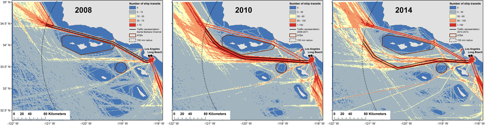

**Figure App.C.4.12.**. A map showing traffic patterns of large commercial shipping vessels through the Sanctuary (2008, 2010, 2014).

**Click for Details**

Traffic patterns of large commercial vessels (cargo and tanker vessels) in the Santa Barbara Channel region for 2008, 2010, and 2014. The number of commercial ship transits is shown, using Automatic Identification System (AIS) data transmitted from ships. Vessels transiting to and from the Ports of Los Angeles/Long Beach that pass by the northern Channel Islands use either the Santa Barbara Channel Traffic Separation Scheme around the north side of the islands, or take routes south of the islands. Data source: USCG AIS data, processed by NMFS; Figure: MSWGSS 2016

###### Vessel Groundings

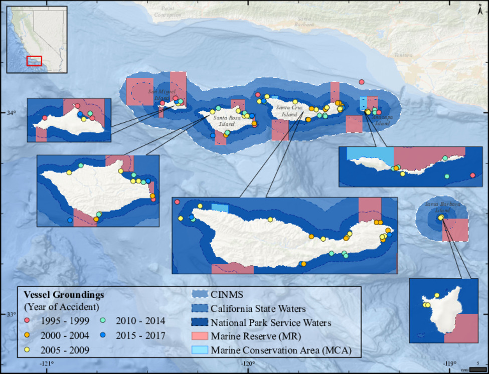

**Click for Details**

#### Visitors

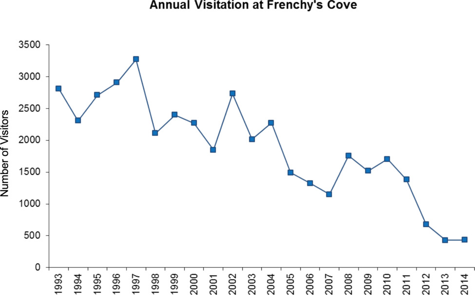

**Figure App.C.4.8.** Annual number of visitors brought to Frenchy’s Cove, Anacapa Island, by the Island Packers Company. At south Frenchy’s Cove and adjacent reefs, Island Packers Company conducts classroom programs for school groups typically during winter and spring months. No records are available for the number of private boaters that went ashore at any of the Channel Islands in the park. Figure: Channel Islands National Park

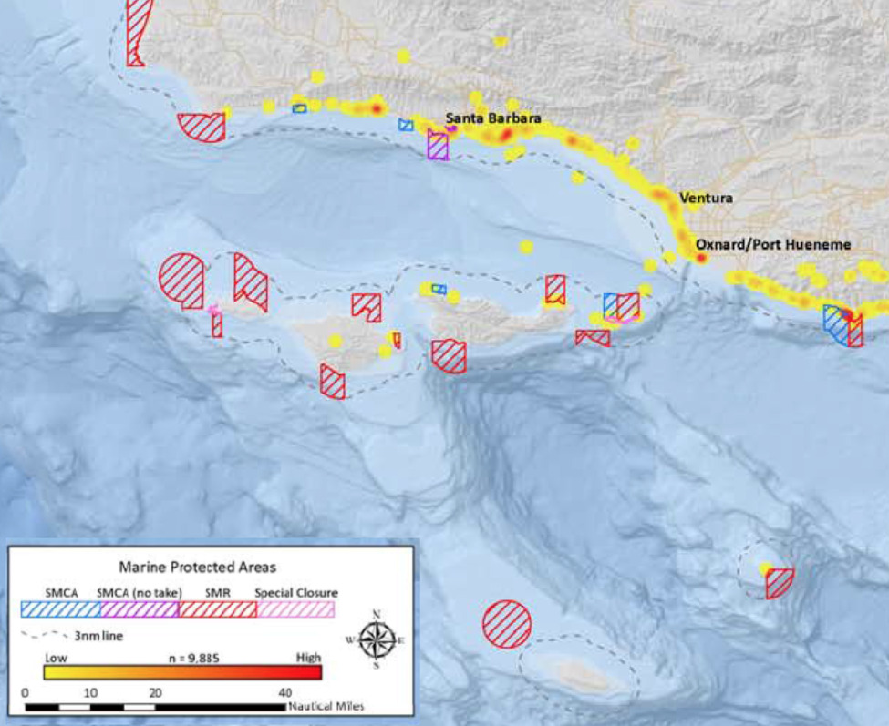

**Figure App.C.4.7. Spatial patterns in coastal recreational activity levels in southern California (all activity types combined). Based on a standing internet panel designed to be demographically representative and surveyed 4,492 individuals in select south coast region counties. Activities at Channel Islands National Marine Sanctuary (CINMS) included: beach-going (SRI), scenic enjoyment (SRI, SCI, Anacapa, SBI), photography (SRI, SCI, Anacapa), birdwatching (SRI, SCI, SBI), and hiking (SRI, SCI). Figure: Chen et al. 2015c

## Human Impacts

#### Contaminants

###### Domoic Acid

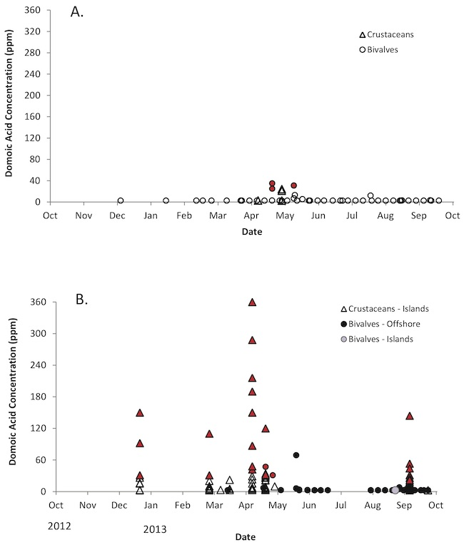

**Figure App.D.7.1.**. A figure showing [domoic acid](https://github.com/marinebon/cinms/blob/master/modals/_glossary.md) levels in commercially-important crustaceans (triangles) and bivalves (circles) collected from the Santa Barbara Channel (2012 - 2013). Red coloration indiciates that the domic acid levels measured above the California Department of Public Health and U.S. Food and Drug Administration action limits.

**Click for Details**

Domoic acid levels in parts per million (ppm) in commercially-important crustaceans (triangles) and bivalves (circles) collected from the Santa Barbara Channel between 2012 and 2013 are shown on the y-axis for (A) animals collected near the shore of the mainland coast, and (B) animals collected offshore the mainland coast or near the northern Channel Islands. In the cases that are colored red, domoic acid levels measured above the California Department of Public Health and U.S. Food and Drug Administration action limits: 20 ppm for meat and 30 ppm for viscera. Figure: [C. Culver/CA Sea Grant](https://caseagrant.ucsd.edu/profile/carolynn-culver), unpublished data

###### Harmful Algal Bloom (May 2015)

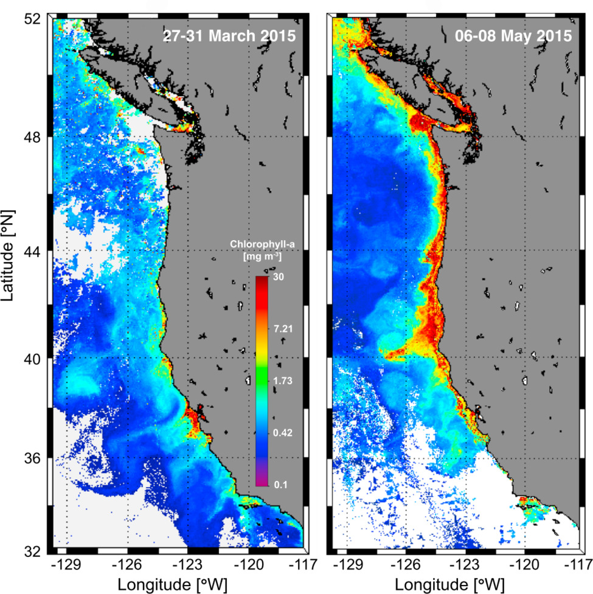

**Figure App.D.7.3.**. A map showing an unprecedented West Coast-wide [harmful algal bloom (HAB)](https://github.com/marinebon/cinms/blob/master/modals/_glossary.md) that extended from the Gulf of Alaska to southern California. March 2015 (left, before the HAB) as compared to May (right, during the HAB).

**Click for Details**

In May 2015, an unprecedented West Coast-wide harmful algal bloom (HAB) extended from the Gulf of Alaska to southern California. The bloom was composed of *Pseudo-nitzschia*, a toxigenic diatom that has the ability to produce domoic acid, a potent neurotoxin that can cause amnesic shellfish poisoning (ASP) and threaten human health if affected shellfish are consumed. These satellite images show chlorophyll-a estimates averaged over the periods of March 27–31, 2015 (left panel), and May, 6–8, 2015 (right panel). Data source: Satellite data were obtained from the National Aeronautics and Space Administration Ocean Biology Processing Group (OBPG) using a combination of the MODerate resolution Imaging Spectroradiometer (MODIS) on Aqua and Visible Infrared Imaging Radiometer Suite (VIIRS) chlorophyll products. Data were processed using standard OBPG processing with 4 kilometer imagery. Figure: McCabe et al. 2016

###### Benthic Response Index - Trend by region

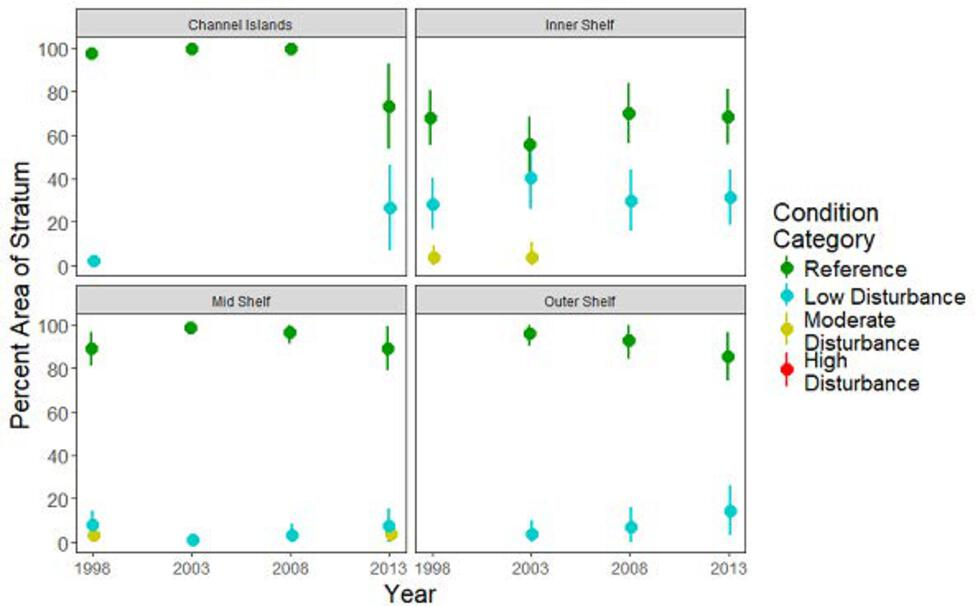

**Figure App.E.11.10.**. A figure showing the relative impact of human activity on the seafloor across different regions of the Southern California Bight, using the Benthic Response Index as an indicator.

**Click for Details**

###### Benthic Response Index - Trend by site

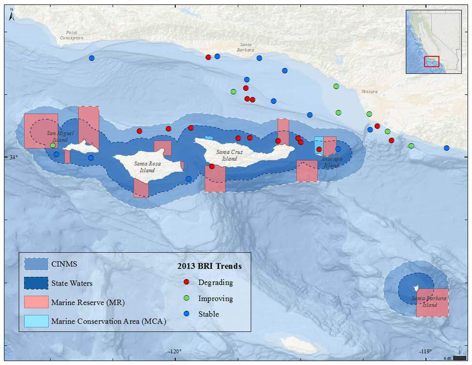

**Figure App.E.11.9.**. A map showing the relative impact of human activity on the seafloor across different regions of the Southern California Bight, using the Benthic Response Index as an indicator.

**Click for Details**

###### Benthic Response Index - Condition by site

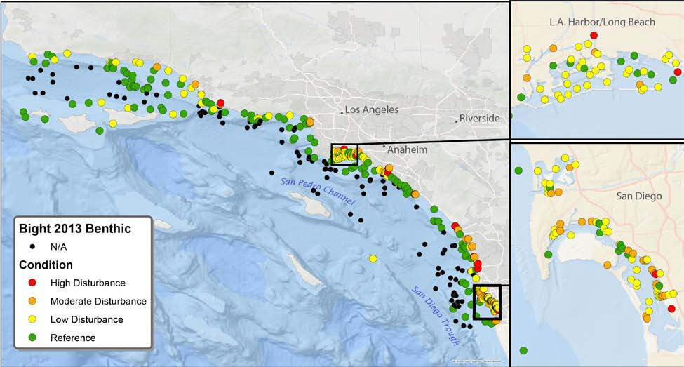

**Figure App.E.11.11.**. A map showing sediment sample locations and their respective Benthic Reponse Index sites from a 2013 Southern California Bight-wide survey. The Benthic Response Index is a measure of the impact of humans on the seafloor.

**Click for Details**

SCCWRP sediment sample locations and their respective Benthic Response Index (BRI) from the 2013 bight-wide survey are shown in the map. In order to create the BRI, infaunal invertebrate communities are characterized based on the proportion of taxa present in a sample that are sensitive to as opposed to tolerant of contaminant levels. Using a composite score of the infauna community, SCCRWP labels sample sites as reference, low impact, moderate impact, or high impact. Figure: K. Schiff/[SCCWRP](https://www.sccwrp.org/)

###### DDT in sediments

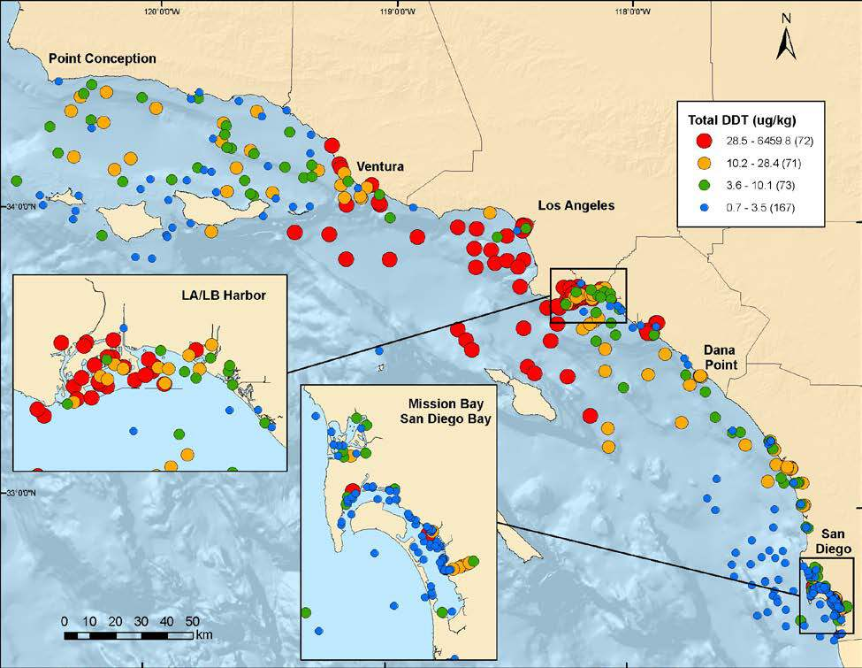

**Figure App.E.11.12.**. A map showing DDT contaminant levels in sediments collected across the Southern California Bight in 2008.

**Click for Details**

Dichlorodiphenyltrichloroethane (DDT) contaminant levels in sediment sampling locations during SCCRWP’s 2008 bight-wide survey are shown in the map. DDT is most prominent around the Ports of Long Beach, Los Angeles, and Santa Monica Bay. DDT is a legacy contaminant, which means it persists in the environment long after introduction. A large amount of DDT in the bight came from the dumping of the contaminant by the Montrose Chemical Company off Palos Verdes until the early 1980s, which is why the surrounding areas have high DDT levels. CINMS is relatively far from the spill site and thus, has limited DDT concentrations in sediments. Figure: Schiff et al. 2011

###### Copper in sediments

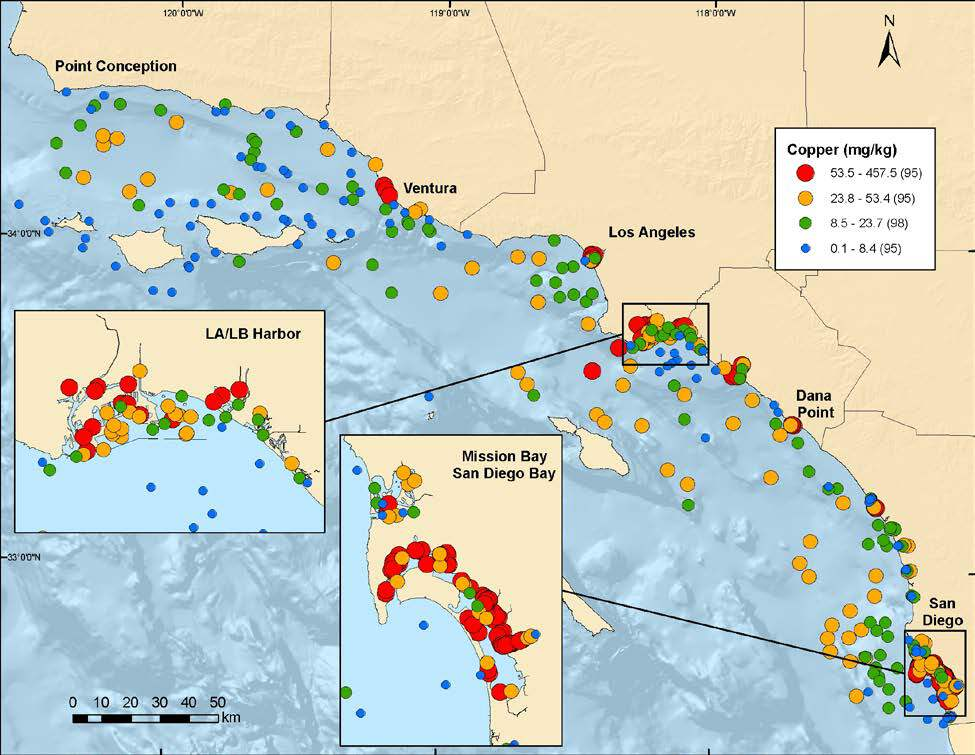

**Figure App.E11.13.**. A map showing copper contaminant levels in sediments collected across the Southern California Bight in 2008.

###### Silver in sediments

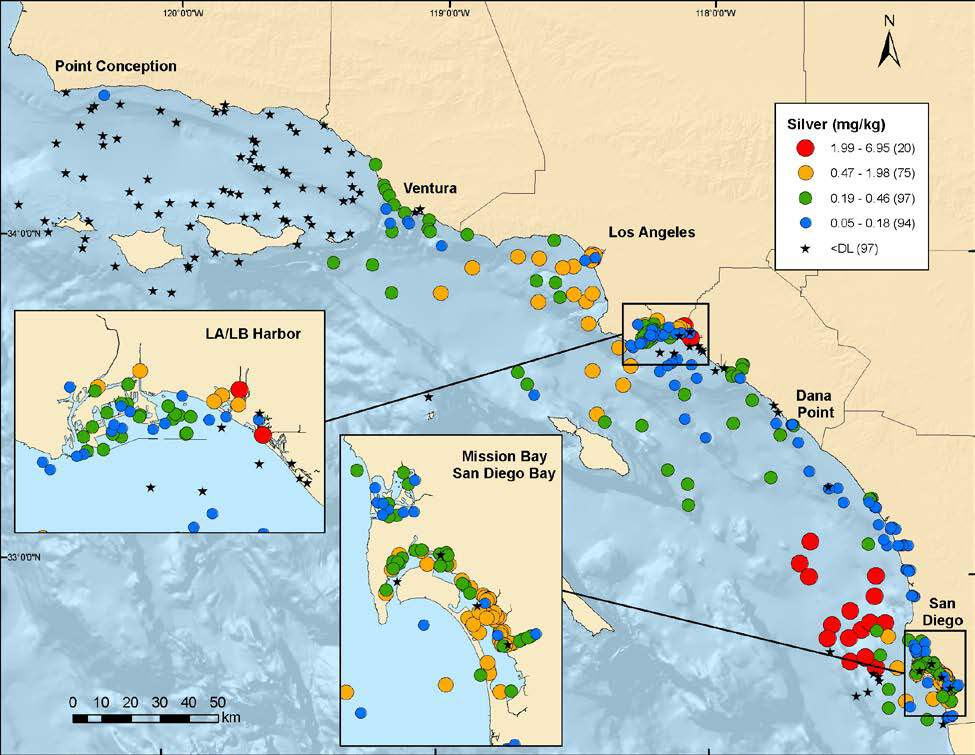

**Figure App.E11.14.**.

**Click for Details**

Silver contaminant levels in sediment sampling locations during SCCRWP’s 2008 bight-wide survey are shown in the map. Silver is a heavy metal contaminant that in high concentrations can be toxic to living marine resources. Concentrations in CINMS and the Santa Barbara Channel are consistently low compared other regions in the Southern California Bight. High concentrations of silver appear to be clustered off the two largest population centers: Los Angeles and San Diego. Figure: Schiff et al. 2011

###### PBDEs in sediments

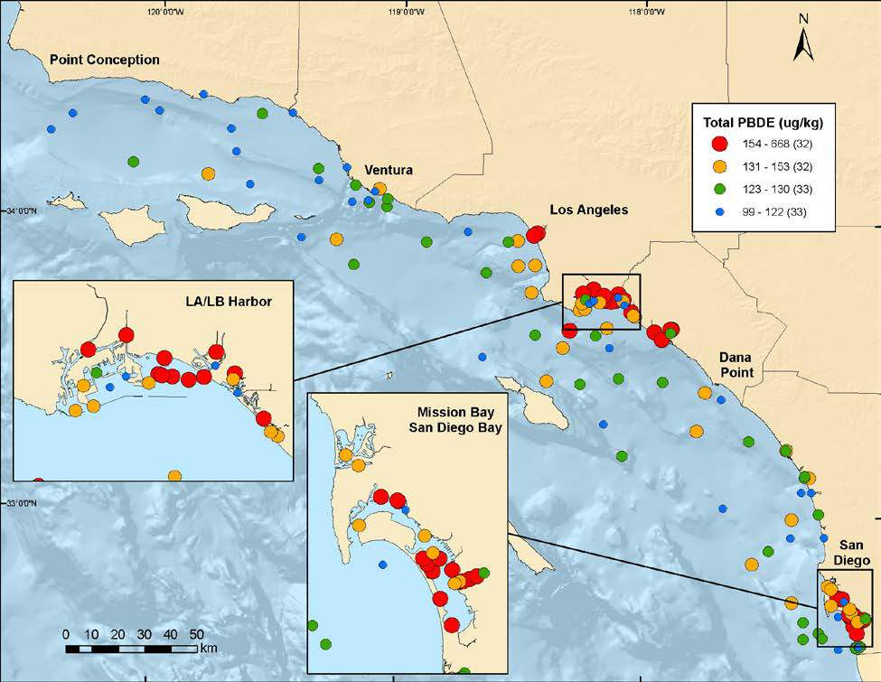

**Figure App.E.11.15.**.

###### Pyrethroids in sediments

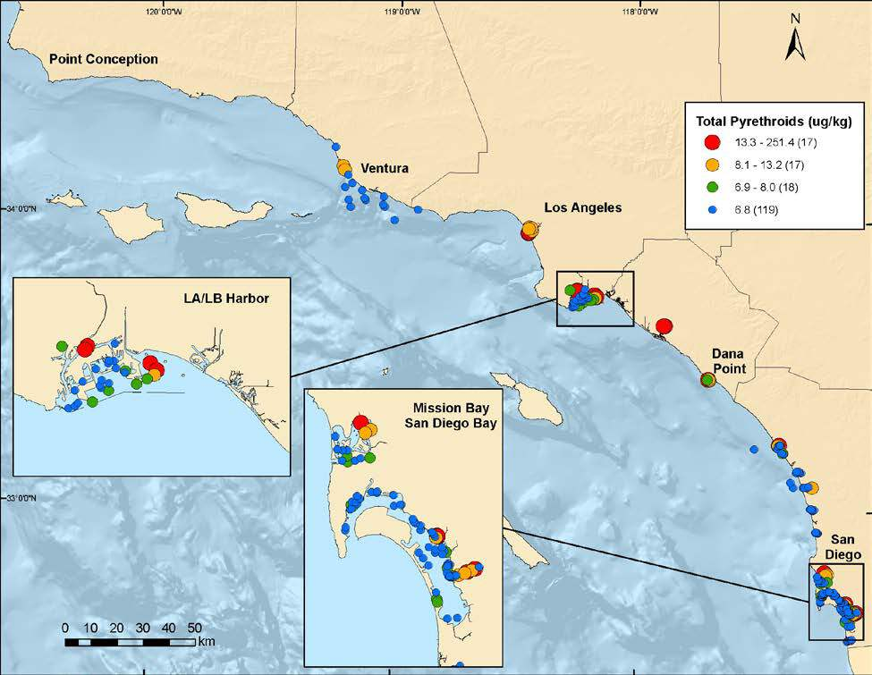

**Figure App.E.11.16.**. A map showing pyrethroid (insecticide) contaminant levels in sediments collected across the Southern California Bight in 2008.

**Click for Details**

Pyrethroids contaminant levels in sediment sampling locations during SCCRWP’s 2008 bight-wide survey are shown in the map. Pyrethroids are typically pollutants coming from insecticide use. In recent years, there has been no agriculture on the islands and thus, pyrethroids are absent from CINMS sediments. Sediments adjacent to CINMS off Ventura have low levels of pyrethroids likely due to agriculture in that area. Figure: Schiff et al. 2011

###### Contaminants in sediments - Trends by region

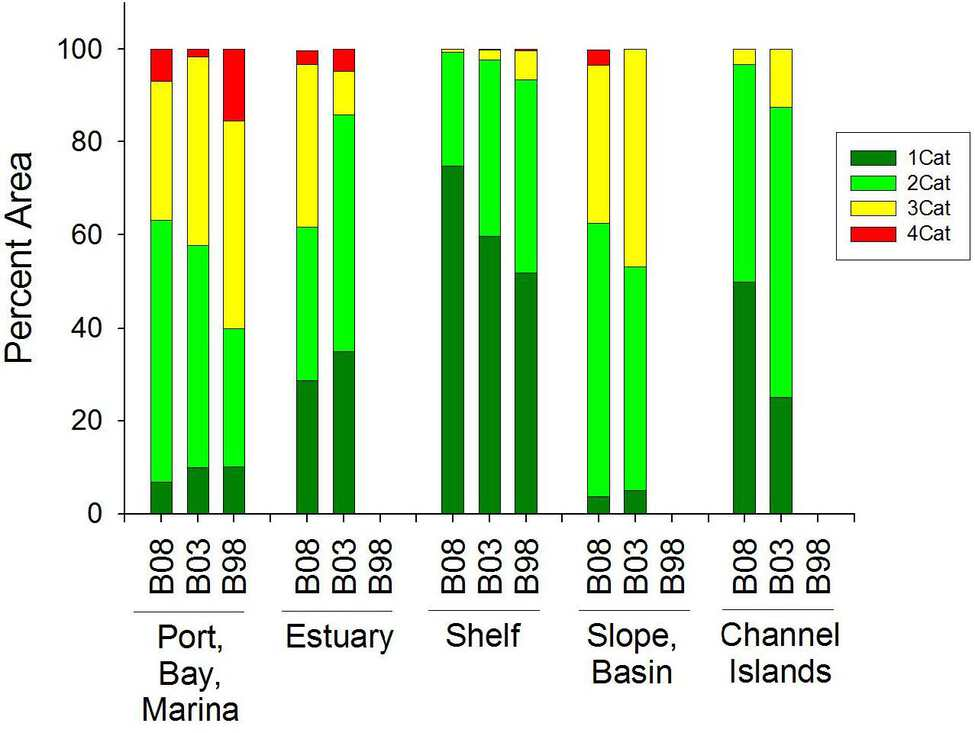

**Figure App.E.11.17.**. A figure showing the amount of impacted sediment in varying categories of exposure to sediment contamination (“Cat”) across five sites and three years.

**Click for Details**

###### Arsenic in mussels

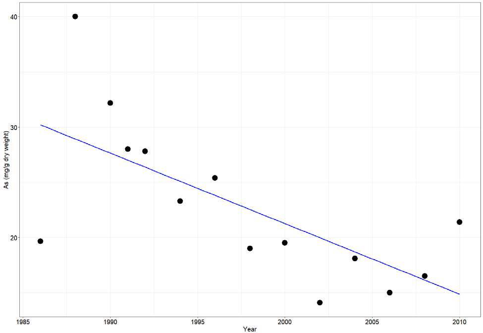

**Figure App.E.11.2.**. A figure showing a time series of arsenic found in mussel tissue from Santa Cruz Island from 1986 - 2010.

**Click for Details**

Time series of arsenic (as μg/g dry weight) in *Mytilus* spp. at Fraser Point, Santa Cruz Island is shown above. Data is from NOAA’s Mussel Watch Program (monitored 1986-2010). Arsenic values have been slowly declining in *Mytilus* spp tissue. Arsenic can impact a number of enzymes and has a widespread effects on a number of organ systems. There are multiple potential explanations for this finding, including limited spatial resolution, limited recent data, possible return to background levels consistent with the southern California mainland after remediation, or improved instrumentation and analytics that have been developed since data collection began. Due to this, more through research and data collection is required to confirm this trend. Figure: D. Whitall/[NOAA, Mussel Watch](https://www.waterboards.ca.gov/water_issues/programs/swamp/mussel_watch.html)

###### Iron in mussels

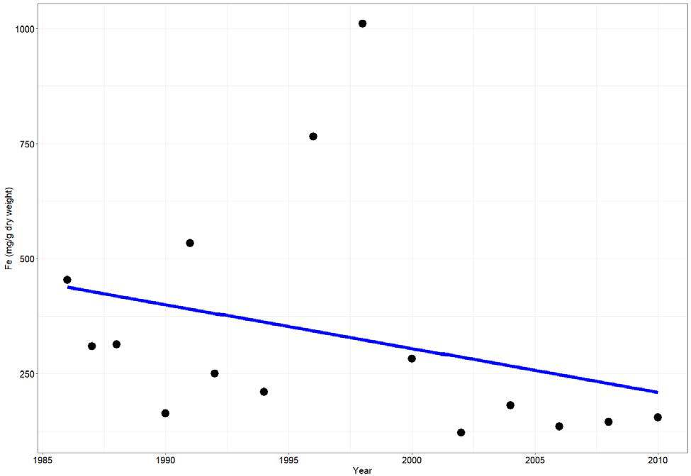

**Figure App.E.11.3.**. A figure showing the trends over time of iron found in mussel tissue from Santa Cruz Island from 1986 - 2010.

**Click for Details**

Time series of iron (as μg/g dry weight) in *Mytilus* spp. at Fraser Point, Santa Cruz Island is shown above. Data is from NOAA’s Mussel Watch Program (monitored 1986–2010). Iron values have been slowly declining in *Mytilus* spp. tissue. There are multiple potential explanations for this finding, including limited spatial resolution, limited recent data, possible return to background levels consistent with the southern California mainland after remediation, or improved instrumentation and analytics that have been developed since data collection began. Due to this, more through research and data collection is required to confirm this trend. Figure: D. Whitall/[NOAA, Mussel Watch](https://www.waterboards.ca.gov/water_issues/programs/swamp/mussel_watch.html)

###### Silver in mussels

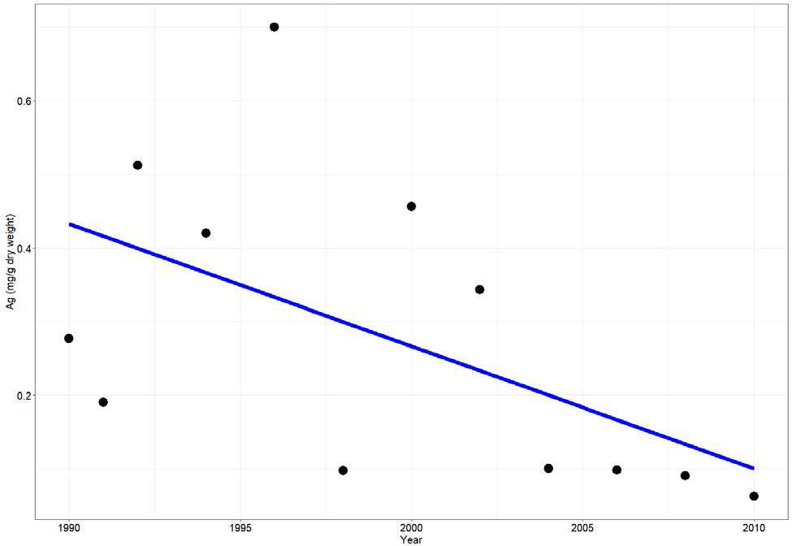

**Click for Details**

Time series of silver (as μg/g dry weight) in *Mytilus* spp. at Fraser Point, Santa Cruz Island is shown above. Data is from NOAA’s Mussel Watch Program (monitored 1986–2010). Silver values have been slowly declining in *Mytilus* spp. tissue. There are multiple potential explanations for this finding, including limited spatial resolution, limited recent data, possible return to background levels consistent with the southern California mainland after remediation, or improved instrumentation and analytics that have been developed since data collection began. Due to this, more through research and data collection is required to confirm this trend. Figure: D. Whitall/[NOAA, Mussel Watch](https://www.waterboards.ca.gov/water_issues/programs/swamp/mussel_watch.html)

###### Heavy metals in mussels

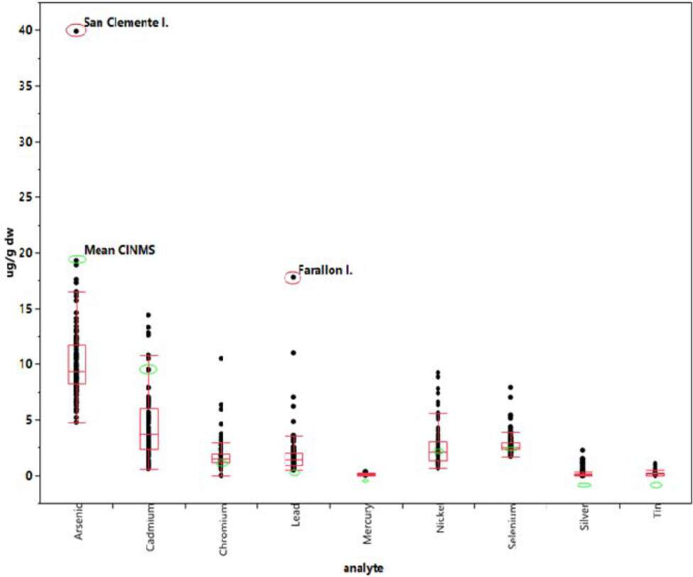

**Figure App.E.11.5.**. A figure showing a coastwide comparison of heavy metals found in mussel tissue from 1986-2010.

**Click for Details**

This graph is a California coastwide comparison of total extractables (TE) from *Mytilus* spp. tissue for heavy metals. Data is from NOAA’s Mussel Watch Program (monitored 1986–2010). The horizontal lines of the red box illustrate the 25th, median, and 75th percentiles, while the top and bottom whiskers represent the 10th and 90th percentiles. Black dots are data points from collection sites and the green ellipsoids represent mean concentration values for metals from sites within CINMS (n = 3). There are multiple potential explanations for this finding, including limited spatial resolution, limited recent data, possible return to background levels consistent with the southern California mainland after remediation, or improved instrumentation and analytics that have been developed since data collection began. Due to this, more through research and data collection is required to confirm this trend. Figure: D. Apeti/[NOAA, Mussel Watch](https://www.waterboards.ca.gov/water_issues/programs/swamp/mussel_watch.html)

###### PAHs in mussels

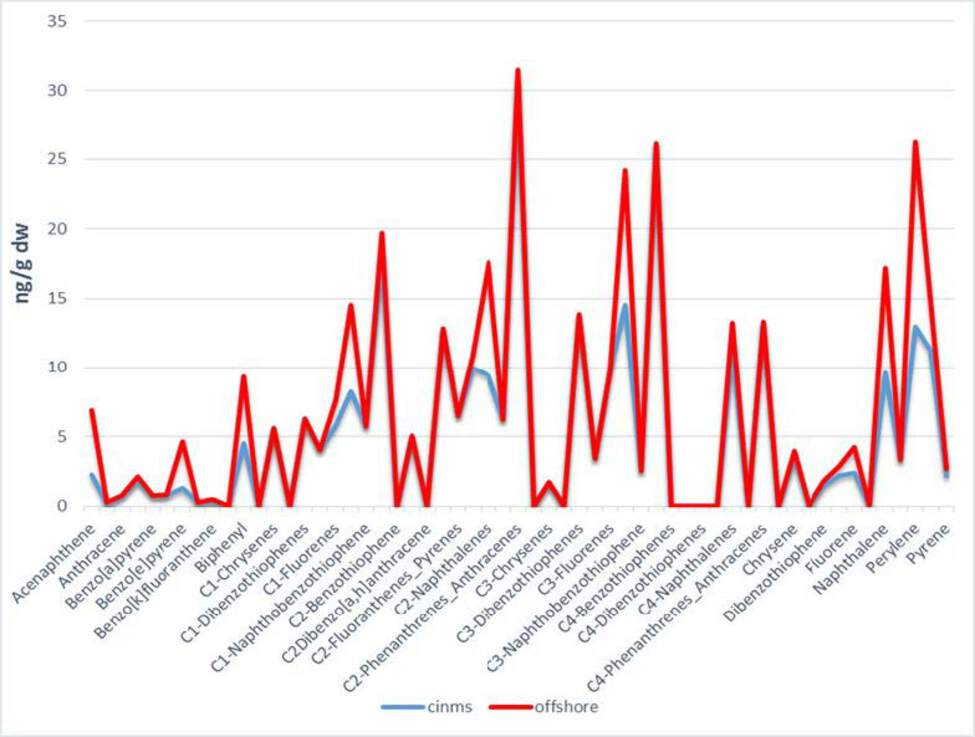

**Figure App.E.11.6.**. A figure showing levels of cancer-causing petroleum-linked chemicals found in the Channel Islands (blue) and offshore sites (red).

**Click for Details**

Mean Total Extractables (TE) for individual Polycyclic Aromatic Hydrocarbons or PAHs are compared between Channel Islands (blue) and other offshore sites (red). PAHs are organic contaminants that are carcinogenic. [Invertebrate](https://github.com/marinebon/cinms/blob/master/modals/_glossary.md) species typically have limited ability to metabolize PAHs; however, they typically do not biomagnify because vertebrates can metabolize them more easily. Concentrations of PAHs are variable, but concentrations at CINMS are usually equivalent, if not lower than other offshore locations. There are multiple potential explanations for this finding, including limited spatial resolution, limited recent data, possible return to background levels consistent with the southern California mainland after remediation, or improved instrumentation and analytics that have been developed since data collection began. Due to this, more through research and data collection is required to confirm this trend. Figure: D. Apeti/[NOAA, Mussel Watch](https://www.waterboards.ca.gov/water_issues/programs/swamp/mussel_watch.html)

#### Marine Debris

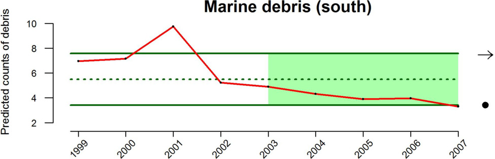

**Figure App.C.4.14.**. Marine debris estimates modeled along the mainland southern California coast based on debris measured by the National Marine Debris Monitoring Program. Marine debris was relatively constant across the last five years of this time series (1999-2007) and within historic levels. Data source: Ribic et al. 2012; Figure: K. Andrews/NOAA